# Ps_restraction

Wenlong

5/9/2018

# 智商捉急的PS作假技术

## 闭门家中坐，锅从天上来

2013年6月，Rajaskehar Anumolu, 一个来自犹他大学 (University of Utah) 化学工程系的Ph.D， 毕业之后在 Nano Letters上中了一篇论文。能够投中一个影响因子(IF) 为12.9的期刊，想必这位印度小哥也是心中暗喜。

然后，文章发表不久，2013年8月，Dr.Garcia在自己的博客中正式爆料，指出印度小哥在文章图片中存在**明显的“伪造行为”**。一石激起千层浪，这篇博文点击量剧增，并被各个热门博客转载。截止到2014年11月15日，该篇博文已经获得了超过37万的点击量！

Nano Letters 迅速开展调查并撤销了已发表的文章；与此同时，犹他大学也公开进行内部调查，调查印度小哥和他老板的学术不端及经费使用情况——印度小哥一时间处于水深火热之中。

到底Dr. Garcia 在自己的博客里爆了什么料，能够引起这么大的反应？请听笔者一一分解。

## 简单的背景介绍

印度小哥是研究纳米材料的，主要研究方法是使用一种类似于高倍数显微镜的设备(TEM)来观察不同角度的纳米材料的性质 (外行解释，如有问题，欢迎指出) 。在论文中，印度小哥附上了TEM照片来展示实验结果，就是这些照片被人指出作假。

## 作假证据 # 1

读者大多都用过PHOTOSHOP吧，这明显就是在PHOTOSHOP (或者类似软件中) 复制下来一个矩形图片，然后粘贴过来并调整到一定角度。更令人捉急的是，印度小哥竟然都不知道PS有个“模糊”功能，能够**模糊粘贴图像和原图像的边界问题**！

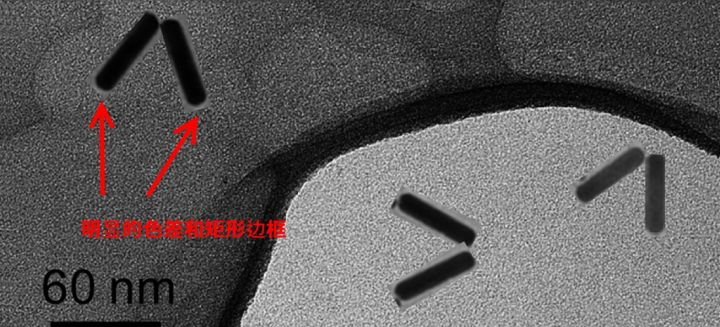

图1

## 作假证据 # 2

模糊功能不知道也就算了，毕竟印度小哥学化学的，不是学**“修图”**的。可是第二点就真的让广大读者怀疑他的智商了。

在看图2中间那对纳米棒，显而易见的矩形边界暂且不提，印度小哥竟然将两个纳米棒重叠起来了——仔细看两个纳米棒的交叉部分，下边的纳米棒的**一部分浅色边界覆盖了上边的纳米棒**！

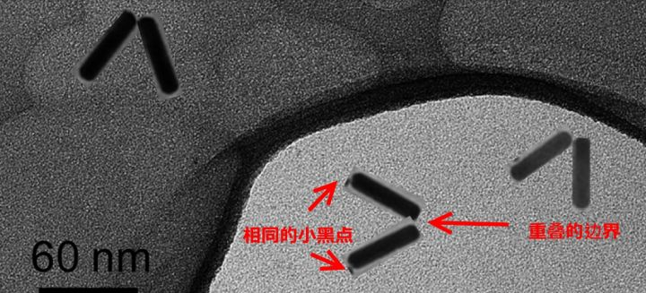

图2

如果分别观察这两根纳米棒，会发现他们的**底部有相同的一个小黑点**：这说明是同一个地方“复制”来的纳米棒啊！机智的笔者竟然都能还原他的操作过程：

> - 先用“矩形”工具选择一个合心意的纳米棒；
> - 复制整个矩形内容；
> - 粘贴一次，调整角度，放好上边的棒棒；
> - 再粘贴一次，调整合适角度，放好下边的棒棒；
> - 搞定收工！

这种“拙劣”的PS技术在这个图片中随处可见，感兴趣的可以去参观一下原文章，点击*原文链接*即可下载，免费的哦~

## 作假证据 # 3

第三点不太明显，不过也让“热心观众”找出来了。图3(来自另外一篇文章)中有两个莫名其妙的灰色“异物”，一个正方形和一个椭圆，如图所示。这种没法解释的修图只能证明这张图片是伪造的。

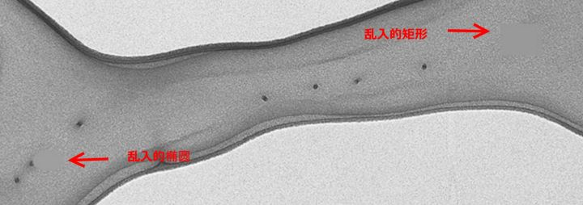

图3

## 后续影响

在这么明显的证据面前，美国网友显示出了卓越的“黑人”技能，以下摘录一部分精彩点评：

> - “That is some impressively bad photoshop. Allegedly.”
> - “I’m going to go with MS paint”
> - “Wow, worst cut and paste job ever!”
> - “If you’re going to commit fraud, work a little harder on it.”
> - “I spend more time photoshoping happy hr posters.”

这位印度小哥在期刊投稿时竟然公然伪造图片，而且其**手段之拙劣，技术之粗糙**让人难以想象，真是替他智商捉急啊！

同时，这么明显的学术不端行为竟然通过了**导师考核、同行评议和编辑终审**，让人不禁对该杂志刊出的文献的质量存疑！

## 处理结果

经过内部调查，2014年11月，犹他大学公布调查结果，**宣布印度小哥需要为所有的学术不端负责，他的学位被收回而且不能在犹他大学工作**，另外的两名作者(包括导师)被*免于责任*；同时，报告还显示该项研究没有花费美国联邦政府的经费，所以不需要其他基金参与调查。

其实就是印度小哥把所有黑锅背了，导师啥事没有，该上班上班，该工作工作，并且没有花联邦政府的基金，所以大事化小小事化了——谁说美帝学术圈没有政治！

现在问题来了，如果真的牵扯到这个学术不端的行为，读者朋友们，**你们认为导师需要负责任吗？**

The end, thanks for reading.

[figure not shown]